# TAD_3dBrowser_analysis

```python
import pandas as pd
import numpy as np
import matplotlib.pyplot as plt
import matplotlib as mpl
%matplotlib inline
import seaborn as sns; sns.set(color_codes=True)
from IPython.core.interactiveshell import InteractiveShell
InteractiveShell.ast_node_interactivity = "all"
import sys
sys.setrecursionlimit(5000)
mpl.style.use('default')
```

#### Saving and uploading environment variables each session

```python
import shelve
filename='./shelve_TAD_3dBrowser_analysis.out'
my_shelf = shelve.open(filename,'n') # 'n' for new
shelved = []
error = []
for key in dir():
    if not(key.startswith('_')):
        try:
            my_shelf[key] = globals()[key]
            shelved.append(str(key))
        except:
            error.append(str(key))
my_shelf.close()

print("## Successfully Shelved: ##")
_ = [print(str(i)) for i in shelved]
print("\n## ERROR Shelving: ##")
_ = [print(str(i)) for i in error]
```

```
## Successfully Shelved: ##
In
InteractiveShell
Out
TAD_master
TAD_master_100k
TAD_master_30k
ax
b
bin_idx
buffer
cell_type_tads
chr1_len
corr
corr100k
corr30k
diff
diff_matrix
error
filename
g
high
i
input_file_list
key
line
low
my_shelf
opened
shelved
ultraconservedSubset
uniqueTAD

## ERROR Shelving: ##
exit
get_ipython
mpl
np
pd
plt
quit
shelve
sns
sys
```

```python
import shelve
filename='./shelve_TAD_3dBrowser_analysis.out'
my_shelf = shelve.open(filename)
opened = []
error = []
for key in my_shelf:
    try:
        globals()[key]=my_shelf[key]
        opened.append(str(key))
    except:
        error.append(str(key))
my_shelf.close()

print("## Successfully Opened: ##")
_ = [print(str(i)) for i in opened]
print("\n## ERROR Shelving: ##")
_ = [print(str(i)) for i in error]
```

```
## Successfully Opened: ##
In
InteractiveShell
Out
TAD_master
TAD_master_100k
TAD_master_30k
ax
b
bin_idx
buffer
cell_type_tads
chr1_len
corr
corr100k
corr30k
diff
diff_matrix
error
filename
g
high
i
input_file_list
key
line
low
my_shelf

## ERROR Shelving: ##
findDistofConservedTADs
opened
shelved
total_corr
unique
win
```

#### Data from 3d_genome_browser TAD coordinates generated from the Dixon 2012 paper pipeline (http://promoter.bx.psu.edu/hi-c/publications.html) found here: /dors/capra_lab/users/bentonml/enhancer_gain_loss/data/reg_domains/tad/3d_genome_browser/

```python
import csv
with open('/dors/capra_lab/users/evonne/TAD/data/3dGenomeBrowser_cellTypes_fileLocs.txt') as f:
    reader = csv.reader(f, delimiter = "\t")
    input_file_list = list(reader)

cell_type_tads = {}

for line in input_file_list:
    cell_type_tads[line[1]] = pd.read_table(line[0], header=None)
    cell_type_tads[line[1]].columns = ['chr','start','stop']

# access data frames in the dictionary like this: cell_type_tads['bladder'].head()
```

### Number of TADs in each cell type

[output not shown]

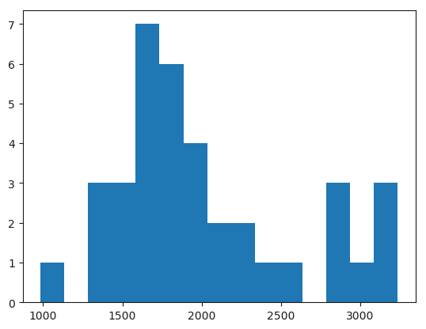

```python
sum = 0
num_of_TADs = []
for key in cell_type_tads:
    print(key + ":   " + str(len(cell_type_tads[key])))
    sum = sum + len(cell_type_tads[key])
    num_of_TADs.append(len(cell_type_tads[key]))


print("\n\n\n" + str(sum) + " number of NON unique TADs over 21 unique tissue/cell types")
_ = plt.hist(num_of_TADs, bins=15)
plt.show()
```

### Some summary stats about the TADs

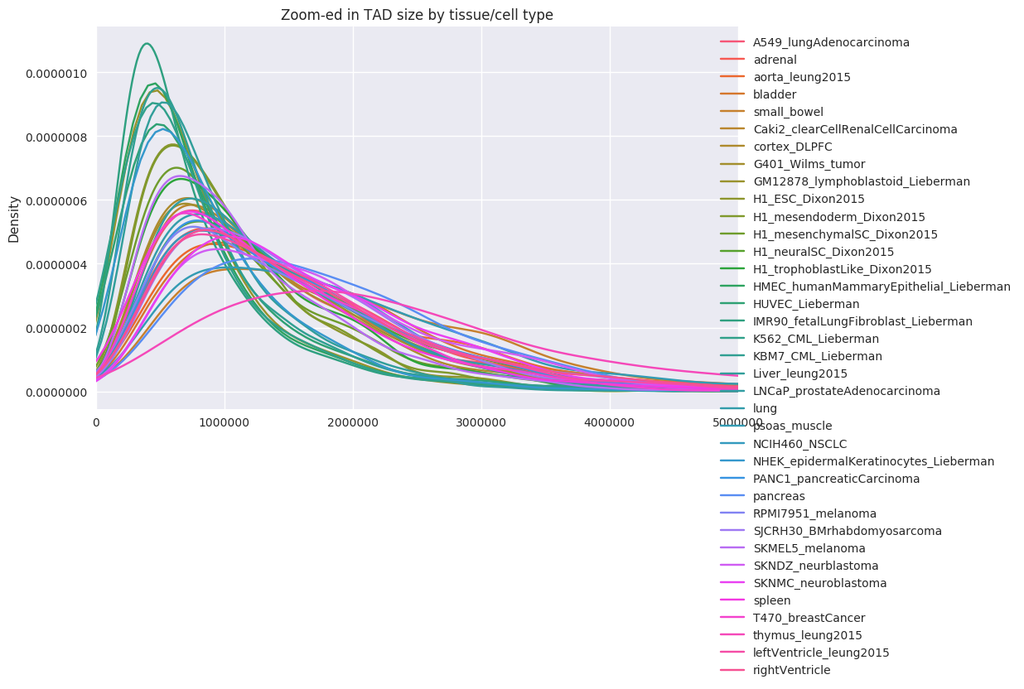

```python
sns.set_palette(sns.husl_palette(37,l=.6))
ax = plt.subplot(111)
diff_matrix = pd.DataFrame()
for key in cell_type_tads:
    diff = pd.DataFrame(cell_type_tads[key]['stop'] - cell_type_tads[key]['start'])
    diff.columns = [key]
    ax = diff.plot.kde(xlim =(0,5000000),figsize=(10,6), title='Zoom-ed in TAD size by tissue/cell type', ax=ax)
    diff_matrix = pd.concat([diff_matrix,diff],axis=1)

ax.legend(loc='upper center', bbox_to_anchor=(1.2, 1))

plt.show()
mpl.style.use('default')
```

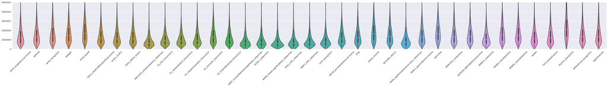

```python
g = sns.set(rc={'figure.figsize':(50,4)})
g = sns.violinplot(data=diff_matrix,figsize=(60,6))
g = plt.xticks(rotation=45)
g = plt.ylim(0,5000000)
```

#### Function to find base pair size between two TADs

```python
def betweenTADsize(data_frame): # input: BED file coordinates

    diff = np.array([])

    for i in range(len(data_frame) - 1):
        if data_frame.loc[i + 1,'chr'] == data_frame.loc[i,'chr']:
            difference =  data_frame.loc[i + 1,'start'] - data_frame.loc[i,'stop']
            diff = np.append(diff, difference)

    return(pd.DataFrame(diff)) # returns data frame of the basepair size between TAD boundaries
```

```python
tads_merged  = pd.DataFrame(columns = ['chr','start','stop'])

for key in cell_type_tads:
    tads_merged = pd.merge(tads_merged,cell_type_tads[key],how='outer',sort=True)

tads_merged = tads_merged.drop_duplicates() # there shouldnt be any duplicates but drop them if there are
print(str(len(tads_merged)) + " number of UNIQUE TADs of 37 unique tissue/cell types if given no \"buffer\" for the start/stop location")
```

```
47149 number of UNIQUE TADs of 37 unique tissue/cell types if given no "buffer" for the start/stop location
```

### interTAD distances by tissue/cell type

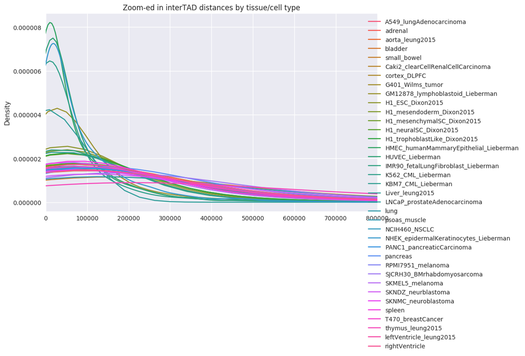

```python
sns.set_palette(sns.husl_palette(37,l=.6))
ax = plt.subplot(111)
diff_matrix = pd.DataFrame()
for key in cell_type_tads:
    diff = betweenTADsize(cell_type_tads[key])
    diff.columns = [key]
    ax = diff.plot.kde(xlim = (0,800000), figsize=(10,6), title='Zoom-ed in interTAD distances by tissue/cell type', ax=ax)
    diff_matrix = pd.concat([diff_matrix,diff],axis=1)
    #diff.describe()
ax.legend(loc='upper center', bbox_to_anchor=(1.2, 1))

plt.show()
mpl.style.use('default')
```

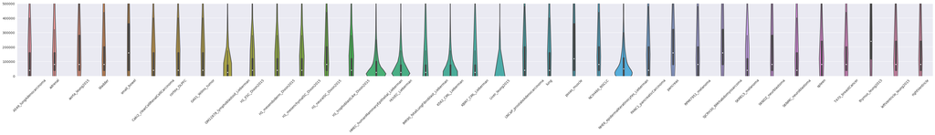

```python
g = sns.set(rc={'figure.figsize':(50,4)})
g = sns.violinplot(data=diff_matrix,figsize=(60,6))
g = plt.xticks(rotation=45)
g = plt.ylim(0,500000)
```

Note: some of the TAD boundaries probably truely represent the same TAD boundary but start/stop at a slightly different spot

#### Create one master TAD list with intervals for TAD start and stop sites

```python
def createMasterTADList(buffer, tads_merged):
    ## Input:
    # buffer: integer which is the window of the buffer (if you give 200KB you add 100kb and subtract 100kb to look for other TAD boundaries)
    # tads_merged: a list of all the TAD boundaries merged
    buffer = buffer*2
    tmp = tads_merged.copy(deep=True)
    TAD_master = []

    while len(tmp) != 0:
        start = tmp.loc[0,'start']
        stop = tmp.loc[0,'stop']
        chrom = tmp.loc[0,'chr']
        start_min = start - buffer
        start_max = start + buffer
        stop_min = stop - buffer
        stop_max = stop + buffer
        tmp.drop(tmp[(tmp['chr'] == chrom) & (tmp['start'] > start_min) & (tmp['start'] < start_max) & (tmp['stop'] > stop_min) & (tmp['stop'] < stop_max)].index, inplace=True)
        tmp = tmp.reset_index(drop=True)
        TAD_master.append([chrom,start_min,start_max,stop_min,stop_max])

    del tmp

    TAD_master = pd.DataFrame(np.vstack(TAD_master))
    TAD_master.columns = ['chr','start_min','start_max','stop_min','stop_max']

    TAD_master = TAD_master.apply(pd.to_numeric, errors = 'ignore')

    return(TAD_master)
```

```python
# Note: this may take some time to run

buffer = 15000
TAD_master_30k = createMasterTADList(buffer,tads_merged)
print(str(len(TAD_master_30k)) + " number of UNIQUE TADs of 37 unique tissue/cell types if given a " + str(buffer) + "bp \"buffer\" for the start/stop location")

buffer = 1
TAD_master = createMasterTADList(buffer,tads_merged)
print(str(len(TAD_master)) + " number of UNIQUE TADs of 37 unique tissue/cell types if given a " + str(buffer) + "bp \"buffer\" for the start/stop location")

buffer = 50000
TAD_master_100k = createMasterTADList(buffer,tads_merged)
print(str(len(TAD_master_100k)) + " number of UNIQUE TADs of 37 unique tissue/cell types if given a " + str(buffer) + "bp \"buffer\" for the start/stop location")
```

```
38861 number of UNIQUE TADs of 37 unique tissue/cell types if given a 15000bp "buffer" for the start/stop location
47149 number of UNIQUE TADs of 37 unique tissue/cell types if given a 1bp "buffer" for the start/stop location
21242 number of UNIQUE TADs of 37 unique tissue/cell types if given a 50000bp "buffer" for the start/stop location
```

```python
TAD_master_30k.head()
```

|  | chr | start_min | start_max | stop_min | stop_max |
| --- | --- | --- | --- | --- | --- |
| 0 | chr1 | -30000 | 30000 | 650000 | 710000 |
| 1 | chr1 | -30000 | 30000 | 1810000 | 1870000 |
| 2 | chr1 | -30000 | 30000 | 3330000 | 3390000 |
| 3 | chr1 | -30000 | 30000 | 3370000 | 3430000 |
| 4 | chr1 | -30000 | 30000 | 3570000 | 3630000 |

#### Function to run through a bed and add a column to the master TAD list, 1 represents that TAD does exist in the bed file, and 0 represents that it does not exist

```python
def findTADinCellTypes(data_frame, stringOfCellTypeName, TAD_total):
    ## Input:
    # data_frame: BED file coordinates data frame - cell type specific
    # stringOfCellTypeName: string describing the cell type name
    # TAD_total: dataframe of all merged TADs - the "master" list

    TAD_total[stringOfCellTypeName] = 0

    for i in range(len(data_frame)):
        index = TAD_total[(TAD_total['chr'] == data_frame.loc[i,'chr']) & (TAD_total['start_min'] < data_frame.loc[i,'start']) & (TAD_total['start_max'] > data_frame.loc[i,'start']) & (TAD_total['stop_min'] < data_frame.loc[i,'stop']) & (TAD_total['stop_max'] > data_frame.loc[i,'stop'])].index
        TAD_total.loc[index,stringOfCellTypeName] = 1
    return TAD_total
```

```python
#Note: this may take some time to run
#findTADinCellTypes(cell_type_tads['bladder'],'bladder',TAD_master).head()

for key in cell_type_tads:
    TAD_master_30k = findTADinCellTypes(cell_type_tads[key], key, TAD_master_30k)
    TAD_master = findTADinCellTypes(cell_type_tads[key], key, TAD_master)
    TAD_master_100k = findTADinCellTypes(cell_type_tads[key], key, TAD_master_100k)
```

```python
#g = sns.clustermap(TAD_master.drop(['chr','start_min','start_max','stop_min','stop_max'],axis=1), figsize=(14,14))
```

```python
#g = sns.clustermap(TAD_master_30k.drop(['chr','start_min','start_max','stop_min','stop_max'],axis=1), figsize=(14,14))
```

```python
#g = sns.clustermap(TAD_master_100k.drop(['chr','start_min','start_max','stop_min','stop_max'],axis=1), figsize=(14,14))
```

different clustering method:

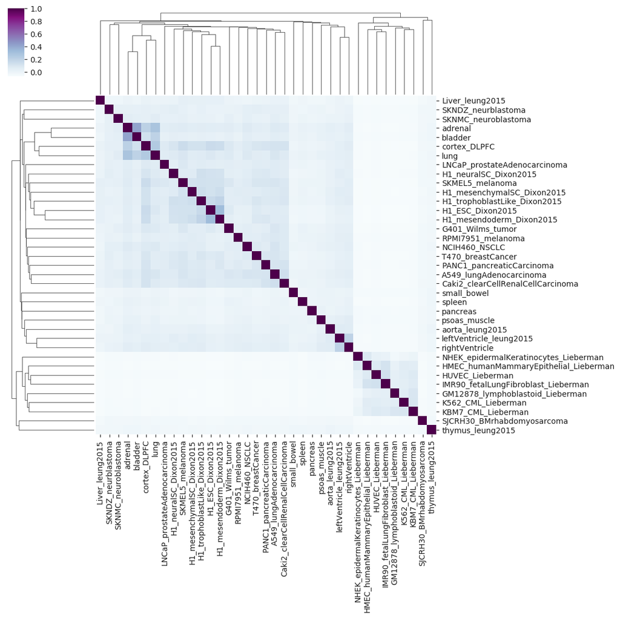

```python
# Correlation matrix between tissue types, two different ways

corr = TAD_master.drop(['chr','start_min','start_max','stop_min','stop_max'],axis=1).corr()
corr30k = TAD_master_30k.drop(['chr','start_min','start_max','stop_min','stop_max'],axis=1).corr()
corr100k = TAD_master_100k.drop(['chr','start_min','start_max','stop_min','stop_max'],axis=1).corr()

g = sns.clustermap(corr, cmap="BuPu")
g = plt.setp(g.ax_heatmap.yaxis.get_majorticklabels(), rotation=0) # rotating the y-axis labels
```

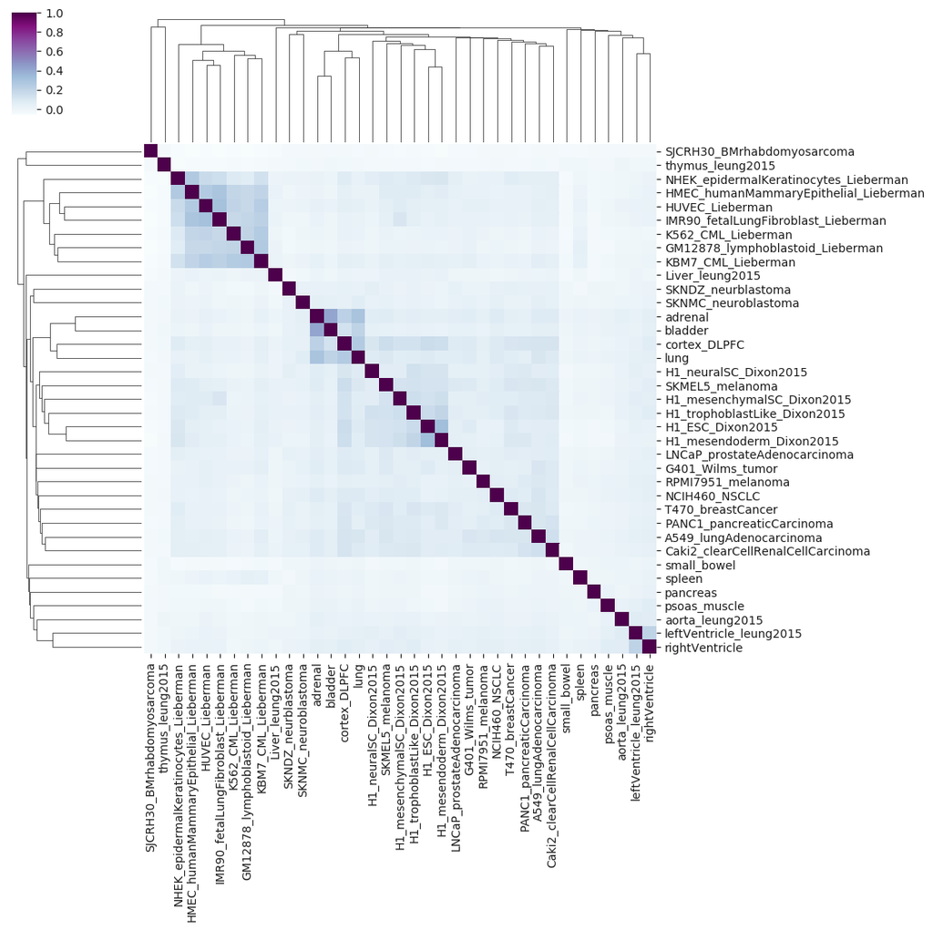

```python
g = sns.clustermap(corr30k, cmap="BuPu")
g = plt.setp(g.ax_heatmap.yaxis.get_majorticklabels(), rotation=0) # rotating the y-axis labels
```

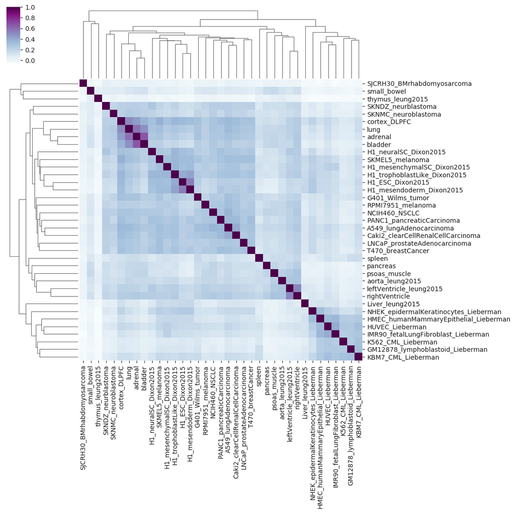

```python
g = sns.clustermap(corr100k, cmap="BuPu")
g = plt.setp(g.ax_heatmap.yaxis.get_majorticklabels(), rotation=0) # rotating the y-axis labels
```